# Pesca - Desembarques de capturas marítimas

Leonel Fernando Cejas

**Introducción** PRUEBA VISUALIZACIÓN 2

El trabajo se realiza a partir de bases de datos públicas brindadoas por el sitio https://www.datos.gob.ar/ . Los datos del presente informe fueron provistos por la Subsecretaría de Pesca y Acuicultura de la República Argentina. Comprenden las capturas pesqueras realizadas por buques que operan dentro de la ZEE de la República Argentina en el período de 2010 a 2018. Intentaremos brindar un panorama completo de la producción pesquera nacional, haciendo hincapié en sus principales características ¿que especies se capturan?, ¿cuales son los principales puertos según el volumen y la diversificación de las capturas? ¿los buques mas grandes poseen un impacto mayor sobre el total de lo capturado?

** En primer lugar hacemos una exploración de los datos y seguidamente asignamos a una variable la base de datos completa con la que elegí trabajar**

```r
captura_puerto_flota_2010_2018 <- read_csv("datos/captura-puerto-flota-2010-2018.csv",
                                           locale = locale(encoding = "windows-1252"))
str(captura_puerto_flota_2010_2018)
```

```
## spc_tbl_ [41,340 × 13] (S3: spec_tbl_df/tbl_df/tbl/data.frame)
##  $ fecha           : chr [1:41340] "2010-01" "2010-01" "2010-01" "2010-01" ...
##  $ flota           : chr [1:41340] "Costeros" "Costeros" "Costeros" "Rada o ría" ...
##  $ puerto          : chr [1:41340] "Caleta Cordova" "Caleta Cordova" "Caleta Cordova" "Caleta Cordova" ...
##  $ provincia       : chr [1:41340] "Chubut" "Chubut" "Chubut" "Chubut" ...
##  $ provincia_id    : chr [1:41340] "26" "26" "26" "26" ...
##  $ departamento    : chr [1:41340] "Escalante" "Escalante" "Escalante" "Escalante" ...
##  $ departamento_id : chr [1:41340] "26021" "26021" "26021" "26021" ...
##  $ latitud         : num [1:41340] -45.7 -45.7 -45.7 -45.7 -45.7 ...
##  $ longitud        : num [1:41340] -67.4 -67.4 -67.4 -67.4 -67.4 ...
##  $ categoria       : chr [1:41340] "Peces" "Peces" "Peces" "Crustáceos" ...
##  $ especie         : chr [1:41340] "Merluza hubbsi" "Pez gallo" "Rayas nep" "Centolla" ...
##  $ especie_agrupada: chr [1:41340] "Merluza hubbsi S41" "otras especies" "Rayas (sin V. Cost)" "Centolla" ...
##  $ captura         : num [1:41340] 386114 4367 13 48218 935 ...
##  - attr(*, "spec")=
##   .. cols(
##   ..   fecha = col_character(),
##   ..   flota = col_character(),
##   ..   puerto = col_character(),
##   ..   provincia = col_character(),
##   ..   provincia_id = col_character(),
##   ..   departamento = col_character(),
##   ..   departamento_id = col_character(),
##   ..   latitud = col_double(),
##   ..   longitud = col_double(),
##   ..   categoria = col_character(),
##   ..   especie = col_character(),
##   ..   especie_agrupada = col_character(),
##   ..   captura = col_double()
##   .. )
##  - attr(*, "problems")=<externalptr>
```

Debido a que la variable “fecha” se encuentra en formato de caracteres se procede a convertirla a formato fecha

```r
captura_puerto_flota_2010_2018 <-
  captura_puerto_flota_2010_2018 |>
  mutate(fecha = ym (fecha))
```

```r
colnames(captura_puerto_flota_2010_2018)
```

```
##  [1] "fecha"            "flota"            "puerto"           "provincia"
##  [5] "provincia_id"     "departamento"     "departamento_id"  "latitud"
##  [9] "longitud"         "categoria"        "especie"          "especie_agrupada"
## [13] "captura"
```

**Especies del Mar Argentino**

La plataforma continental argentina es una de las mas extensas y mas ricas en biodiversidad del mundo. Nuestro país posee derechos exclusivos de explotar los recursos marítimos hasta la milla 200. Mas allá de este límite comienzan las denominadas “aguas internacionales”. Las siguientes especies son capturadas por buques de bandera argentina y descargan lo capturado en puertos argentinos.

```r
lista_de_especies <-
  unique(captura_puerto_flota_2010_2018$especie) |>
  print()
```

```
##  [1] "Merluza hubbsi"            "Pez gallo"
##  [3] "Rayas nep"                 "Centolla"
##  [5] "Otras especies de peces"   "Langostino"
##  [7] "Calamar Illex"             "Savorín"
##  [9] "Palometa"                  "Vieira (callos)"
## [11] "Cangrejo"                  "Calamar Loligo"
## [13] "Caracol"                   "Mejillón"
## [15] "Abadejo"                   "Anchoa de banco"
## [17] "Bacalao austral"           "Bagre"
## [19] "Besugo"                    "Brótola"
## [21] "Caballa"                   "Castañeta"
## [23] "Corvina blanca"            "Gatuzo"
## [25] "Granadero"                 "Jurel"
## [27] "Lenguados nep"             "Mero"
## [29] "Pampanito"                 "Pargo"
```

[output cut: 30 more lines]

** Principales 10 especies en descargas **

```r
captura_puerto_flota_2010_2018_2<-
  captura_puerto_flota_2010_2018 |>
  mutate(especie = fct_lump(especie, n = 10)) |>
  filter(especie != "other") |>
  count(especie, sort = TRUE) |>
  print()
```

```
## # A tibble: 11 × 2
##    especie            n
##    <fct>          <int>
##  1 Other          24259
##  2 Merluza hubbsi  2947
##  3 Rayas nep       2141
##  4 Pez gallo       1639
##  5 Lenguados nep   1636
##  6 Pescadilla      1535
##  7 Langostino      1519
##  8 Gatuzo          1514
##  9 Corvina blanca  1420
## 10 Mero            1401
## 11 Salmón de mar   1329
```

```r
especies_repre <-
  captura_puerto_flota_2010_2018 |>
  filter (especie %in% c("Merluza hubbsi", "Rayas nep", "Pez gallo", "Lenguados nep", "Pescadilla", "Langostino", "Gatuzo", "Corvina blanca", "Mero","Merluza negra"))
```

El siguiente cuadro nos muestra la variación del la captura de las principales especies durante el período de estudio. La captura está expresada en kilogramos.

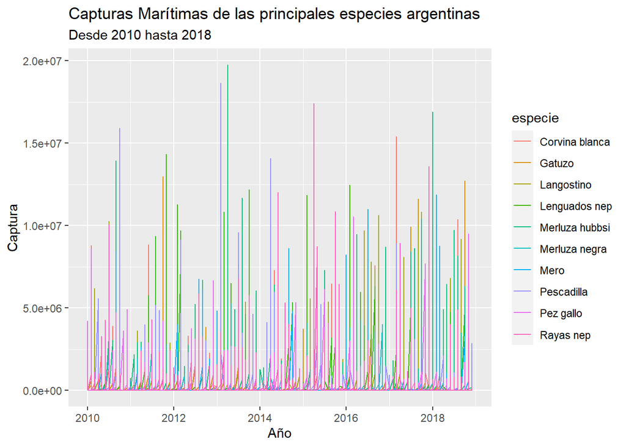

```r
  ggplot(data = especies_repre, mapping = aes(x = fecha, y = captura)) +
  geom_line (aes(colour = especie))+
  labs(title = "Capturas Marítimas de las principales especies argentinas",
       subtitle = "Desde 2010 hasta 2018",
       x = "Año",
       y = "Captura")
```

Principales especies con su volumen de captura en kilogramos. Se destaca el principal recurso marítimo de la plataforma continental argentina, la merluza común o merluza hubbsi.Con picos históricos de captura en 2013 y 2018.

```r
esp_repre_kilos<-
  especies_repre |>
  mutate(total_puerto = sum(captura, na.rm = TRUE)) |>
  group_by(especie) |>
  summarise(total_especie = sum(captura)) |>
  print()
```

```
## # A tibble: 10 × 2
##    especie        total_especie
##    <chr>                  <dbl>
##  1 Corvina blanca     202969593
##  2 Gatuzo             191953356
##  3 Langostino         277499104
##  4 Lenguados nep      326157521
##  5 Merluza hubbsi     543834050
##  6 Merluza negra       29511946
##  7 Mero               205532788
##  8 Pescadilla         301005225
##  9 Pez gallo          198594760
## 10 Rayas nep          361070485
```

```r
repre_esp_tot<-
  esp_repre_kilos |>
  mutate(captura_total= sum(total_especie, na.rm = TRUE)) |>
  mutate(especie_sobre_total = total_especie/captura_total) |>
  arrange(-especie_sobre_total) |>
  print()
```

```
## # A tibble: 10 × 4
##    especie        total_especie captura_total especie_sobre_total
##    <chr>                  <dbl>         <dbl>               <dbl>
##  1 Merluza hubbsi     543834050    2638128828              0.206
##  2 Rayas nep          361070485    2638128828              0.137
##  3 Lenguados nep      326157521    2638128828              0.124
##  4 Pescadilla         301005225    2638128828              0.114
##  5 Langostino         277499104    2638128828              0.105
##  6 Mero               205532788    2638128828              0.0779
##  7 Corvina blanca     202969593    2638128828              0.0769
##  8 Pez gallo          198594760    2638128828              0.0753
##  9 Gatuzo             191953356    2638128828              0.0728
## 10 Merluza negra       29511946    2638128828              0.0112
```

**Sobre los puertos**

Se observa una preponderancia de los puertos de la provincia de Buenos Aires, destacándose, sobre todo, el Puerto de Mar Del Plata. Mar del Plata es el puerto mas grande del país y uno de los mas importantes de Sudamérica.

```r
pu<-
  captura_puerto_flota_2010_2018 %>%
  na.omit() |>
  group_by(puerto) %>%
  summarise(captura = sum(captura)) |>
  arrange(-captura) |>
  print()
```

```
## # A tibble: 21 × 2
##    puerto                   captura
##    <chr>                      <dbl>
##  1 Mar del Plata         3735595329
##  2 General Lavalle        927233245
##  3 Necochea / Quequén     797547895
##  4 Caleta Olivia / Paula  387958427
##  5 Comodoro Rivadavia     255214010
##  6 Bahía Blanca           159555542
##  7 Camarones              154086945
##  8 Puerto Madryn           75728279
##  9 San Antonio Oeste       50357651
## 10 Puerto Deseado          46659415
## # ℹ 11 more rows
```

**El siguiente cuadro nos muestra la captura total en kilogramos según el puerto donde se produjo la descarga** Se destaca , por lejos, el puerto de Mar del Plata. Esta asimetría en el destino que los buques usan para descargar lo capturado ha provocado el pedido y el reclamo de los puertos patagónicos de una distribución mas equitativa, ya que el puerto en el cual se descargan las especies capturadas es de suma importancia para la economía y la generación de empleo local.

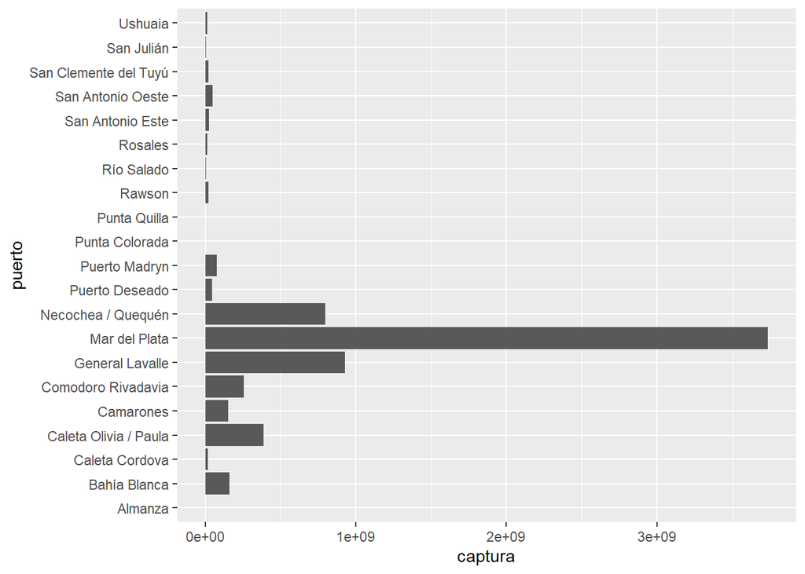

```r
  pu |>
  ggplot(aes(captura, puerto))+
  geom_col()
```

Por último se puede observar una menor variedad en la cantidad especies que descargan en los puertos patagónicos. Los puertos bonaerense presentan la mayor diversificación, sobre todo con respecto a Santa Cruz y Tierra del Fuego

```r
for_puerto<-
  captura_puerto_flota_2010_2018 %>%
  group_by(puerto)%>%
  count(especie)
```

```r
data_count<-
  for_puerto %>%

  summarise(count = n_distinct(especie))
```

```r
for (g in unique(for_puerto$puerto)) {
    miembros <- filter(for_puerto, puerto == g)


  print(paste("El puerto de", g, "registra una captura de", nrow(miembros), "especie/s"))}
```

```
## [1] "El puerto de Almanza registra una captura de 1 especie/s"
## [1] "El puerto de Bahía Blanca registra una captura de 44 especie/s"
## [1] "El puerto de Caleta Cordova registra una captura de 9 especie/s"
## [1] "El puerto de Caleta Olivia / Paula registra una captura de 22 especie/s"
## [1] "El puerto de Camarones registra una captura de 17 especie/s"
## [1] "El puerto de Comodoro Rivadavia registra una captura de 25 especie/s"
## [1] "El puerto de General Lavalle registra una captura de 51 especie/s"
## [1] "El puerto de Mar del Plata registra una captura de 84 especie/s"
## [1] "El puerto de Necochea / Quequén registra una captura de 60 especie/s"
## [1] "El puerto de Puerto Deseado registra una captura de 39 especie/s"
## [1] "El puerto de Puerto Madryn registra una captura de 47 especie/s"
## [1] "El puerto de Punta Colorada registra una captura de 8 especie/s"
## [1] "El puerto de Punta Quilla registra una captura de 2 especie/s"
## [1] "El puerto de Rawson registra una captura de 37 especie/s"
## [1] "El puerto de Rosales registra una captura de 28 especie/s"
## [1] "El puerto de Río Salado registra una captura de 17 especie/s"
## [1] "El puerto de San Antonio Este registra una captura de 42 especie/s"
## [1] "El puerto de San Antonio Oeste registra una captura de 52 especie/s"
## [1] "El puerto de San Clemente del Tuyú registra una captura de 29 especie/s"
## [1] "El puerto de San Julián registra una captura de 12 especie/s"
## [1] "El puerto de Ushuaia registra una captura de 25 especie/s"
## [1] "El puerto de otros puertos registra una captura de 19 especie/s"
## [1] "El puerto de otros puertos Buenos Aires registra una captura de 49 especie/s"
```

**Capturas por tipo de flota**

Este item nos ayuda a comprender la distribución de la captura de acuerdo a la embarcación utilizada para la pesca. En primer lugar aparecen los mas numerosos, los buque de rada o ría. Son lo mas pequeños y operan sobre las aguas provinciales,más cercanas a la costa hasta una distancia de 12 millas.Conservan el pescado en cajones con hielo y realizan viajes cortos que suelen duran uno o pocos días En un segundo escalón están buques costeros y fresqueros también conservan lo capturado en cajones con hielo pero poseen un tamaño y operatividad mucho mayor que los buques de rada o ria. Sus viajes de pesca, denominados “mareas” pueden durar varios días o semanas. Por último los buques congeladores son los de mayor envergadura. El pescado capturado se procesa y congela a bordo, operando como verdaderas factorías flotantes. Sus mareas pueden durar meses. Las distinciones entre distintos congeladores se realiza en base al arte de pesca (redes, anzuelos, trampas) utilizados para pescar.

```r
captura_puerto_flota_2010_2018 |>
  na.omit() |>
  mutate(total_flota = sum(captura, na.rm = TRUE)) |>
  group_by(flota) |>
  summarise(total_flota = sum(captura)) |>
  arrange(-total_flota) |>
  print()
```

```
## # A tibble: 8 × 2
##   flota                           total_flota
##   <chr>                                 <dbl>
## 1 Rada o ría                       2414204301
## 2 Costeros                         2043141371
## 3 Fresqueros                       1122702424
## 4 Congeladores arrastreros          820219882
## 5 Congeladores tangoneros           200751521
## 6 Congeladores poteros nacionales    63145675
## 7 Congeladores trampas               33923331
## 8 Congeladores palangreros           14361775
```

```
## $x
## [1] "Año"
##
## $y
## [1] "Captura"
##
## $title
## [1] "Capturas Marítimas según tipo de flota"
##
## $subtitle
## [1] "Desde 2010 hasta 2018"
##
## attr(,"class")
## [1] "labels"
```

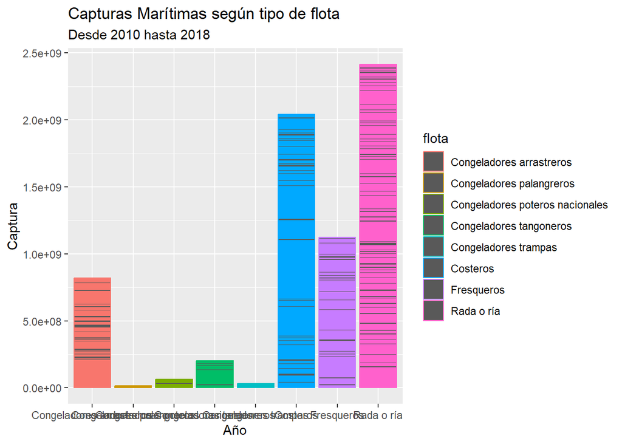

```r
captura_puerto_flota_2010_2018 |>
  na.omit() |>
  ggplot(aes(flota, captura)) +
  geom_col (aes(colour = flota))+
  labs(title = "Capturas Marítimas según tipo de flota",
       subtitle = "Desde 2010 hasta 2018",
       x = "Año",
       y = "Captura") |>
  print()
```